# Knowledge Spillovers in Innovation Economics

### Understanding University Endowment Changes and Patent Concentration Correlations

#### by Maya Niyogi

##### [AS.180.369](https://github.com/llorracc/as.180.369) Tools for Writing a Research Paper in Economics (Fall 2024)

### Motivation

- Prior understanding that **academic research and industry research/activity** go hand-in-hand
- **Urban Economics**: agglomeration forces motivate the creation of cities
  - Consequence of agglomeration forces: knowledge spillovers
  - Results in innovation economies

### What are “Agglomeration Forces”?

- Agglomeration forces: benefits that firms and individuals gain from being near each other.
  - Manifest in **reduced transportation costs, shared resources, and enhanced communication**
  - E.g., Silicon Valley, New York City financial districts
- Key mechanisms:
  1. **Sharing**: Firms share infrastructure, suppliers, and services, reducing costs.
  2. **Matching**: Better matching of workers with jobs due to a larger labor pool.
  3. **Learning**: Increased innovation and productivity through knowledge spillovers and collaboration.

### A Visualization of Agglomeration Forces

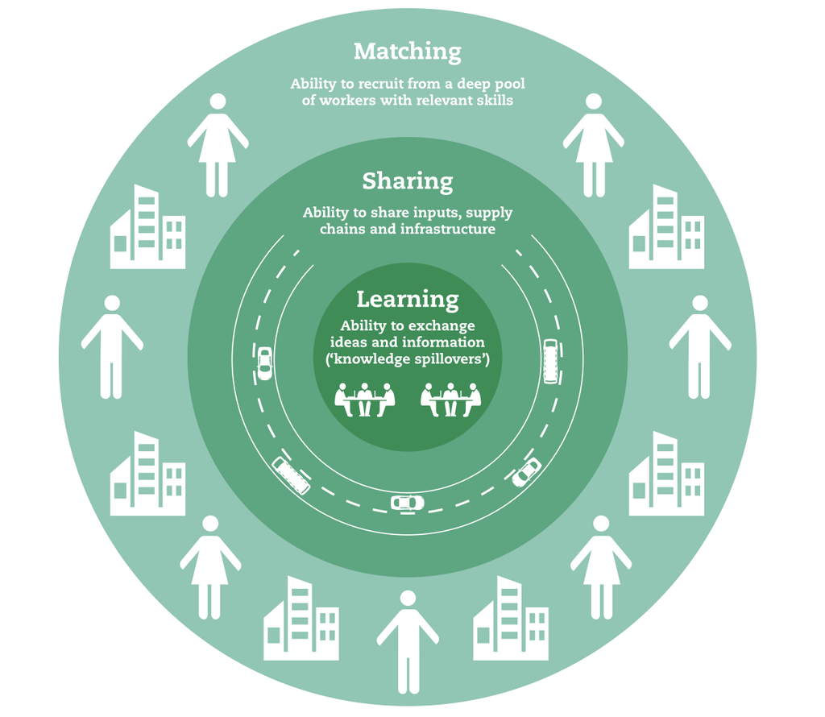

### But What Constitutes a “Spillover”?

- Occur when effects (e.g., information or research) created by one firm or individual benefits others without direct compensation
  - Often happens in clusters of related industries.
- Different types of spillovers:
  1. **Localized Spillover**: Knowledge spreads within a geographic area, enhancing local innovation.
  2. **Technological Spillover**: Innovations in one firm or industry benefit others, leading to overall economic growth.
  3. **Knowledge Spillover**: Increased innovation and productivity through knowledge exchange and collaboration.

### Visualizing a Knowledge Spillover

- **Carlino (2001)**: Knowledge Spillover is *"an exchange of ideas among individuals"*

[figure not shown]

### Importance and Impacts

- **Economic Growth**: Agglomeration forces and knowledge spillovers drive regional development and innovation, leading to cumulative growth and increased returns on investment.
- **Policy implications**:
  - *Education and Training*: Investing in human capital enhances the benefits from agglomeration.
  - *Urban planning*: Encourages the development of "clusters" through zoning and infrastructure investments.
- But there are **challenges**...
  - *Congestion and Costs*: High density can lead to increased living costs and regional congestion.
  - *Inequalities*: Benefits may not be evenly distributed, leading to regional disparities.

### Studies on Agglomeration Forces and Importance

- **Empirical Analysis**: Combes and Gobillon (2015) provided comprehensive analysis of agglomeration economies
  - Found that local density, industrial specialization, and human capital externalities significantly boost productivity and employment
- **Simultaneous Agglomeration and Spillover Effects**: Springer (2004) developed simultaneous equation model to address the endogeneity in traditional models
  - Confirmed that agglomeration and knowledge spillovers jointly enhance economic outcomes

### Studies on Knowledge Spillovers and Importance

- **Study on Networks of Scientists**: Zacchia (2019) demonstrated that interactions between inventors from different firms significantly enhance innovation and productivity
  - Study used network of publicly traded companies to show that R&D performed by connected firms leads to higher innovation rates
- **Impacts on Economic Growth**: Review by MDPI (2024) highlighted that knowledge spillovers contribute to economic resilience and growth, especially during recessions
  - Study analyzed effects in three different countries (Germany, France, Spain), illustrating the positive impact of knowledge diffusion

### However, There are Few Studies *Quantifying* Knowledge Spillovers

- **Bloom (2019)**: Examined effects of Chinese trade on U.S. employment, but does not fully quantify the knowledge spillovers involved
- **Eriksson (2021)**: Explored trade shocks in U.S. manufacturing, with limited focus on the quantification of knowledge spillovers
- **Hausman (2012)**: Investigated role of university innovation in local economic growth, but did not fully measure the extent of knowledge spillovers
- **Abramovsky (2007)**: Analyzed influence of university research on business R&D location, with limited quantification of knowledge spillovers
- **Ellison (2007)**: Provided evidence on industry agglomeration factors, but did not fully quantify knowledge spillovers

## So, We Wanted to Explore this Information Gap...

### The Set-Up

- Want to understand a spatial relationship between **university research** and **industry innovation**
  - From past studies, have seen that these variables are difficult to observe and quantify
- Instrumental variables are beneficial as proxies:
  - University research: University endowment spending serves as instrumental variable as research conducted is a function of university spending.
  - Industry innovation: Regional number of patents filed serves as instrumental variable as patent filings are a precursor to implementation and commercialization of research.

### The Data

- University endowment spending: United States Department of Education's [College Scorecard API](https://collegescorecard.ed.gov/data/api-documentation/) serves statistics about universities nationwide.
  - University spending was computed using `(endowment.begin - endowment.end)`
- Patent count: United States Patent and Trademark Office (USPTO) [Patent View API](https://developer.uspto.gov/api-catalog/patentsview) provides patent concentration data.
- Focused on 2021 data, due to API processing constraints and availability.

### The Models: Spatial Graphs

- Utilized python's [plotly.express](https://plotly.com/python/plotly-express/) package to create interactive spatial maps of university endowment change concentrations and patent concentrations
  - Helped develop visual understanding of concentrations and distributions.

### The Models: Spatial Graphs—Endowment Change Concentrations

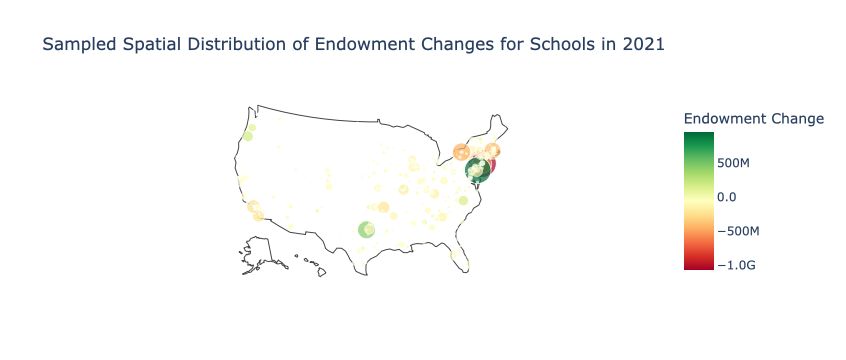

### The Models: Spatial Graphs—Filed Patent Concentrations

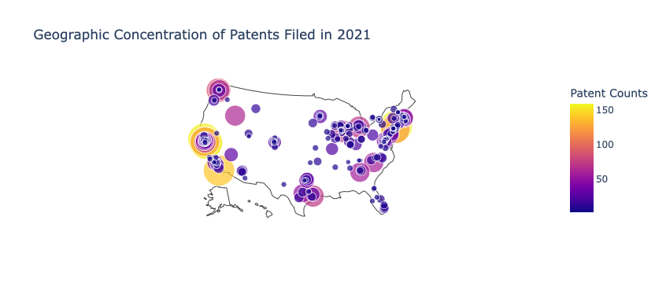

### The Models: Comparing Visual Trends Between Endowment Changes and Patent Concentrations

- Endowment level changes:
  - West Coast (lower California)(Washington), Eastern Midwest, East Coast (upper New York)
- Patent concentrations:
  - West Coast, Upper Midwest, Upper East Coast have heaviest concentrations

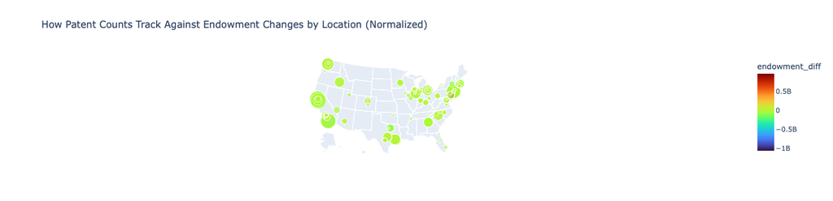

Output: `Correlation between Patent Counts and Endowment Change: -0.147741416615222`

### The Analyses: Understanding Correlations Between Endowment Changes and Patent Concentrations

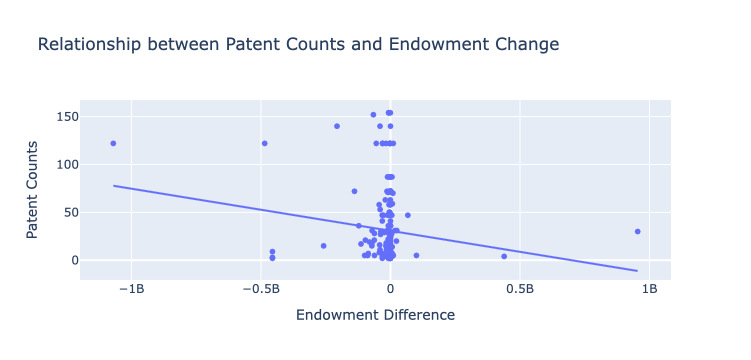

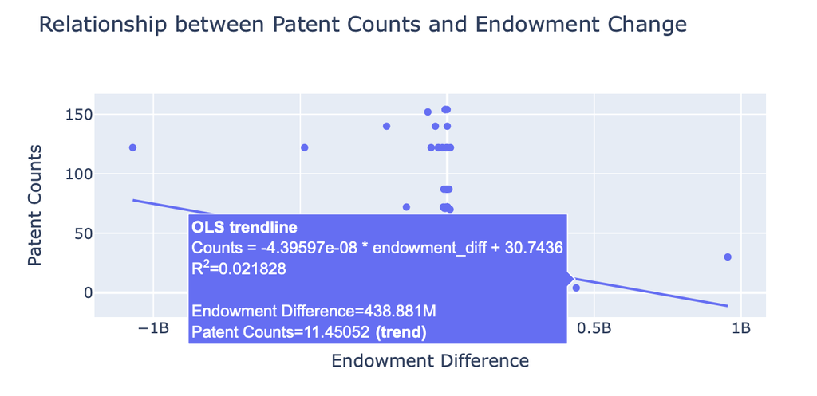

- We see a slight negative relationship, meaning as the change in endowment **increases** (more is spent), the number of patents filed regionally **decreases**
  - That's interesting; let's take a closer look at the numbers!
- Important Caveats!
  1. I have an extremely cursory/low level of familiarity with applied regression analysis before this course.
  2. The instrumental variables may not be the best proxies; I have yet to take Econometrics.
  3. My knowledge has only come from Prof. Carroll, Eitan and Adrian, or ChatGPT/Claude.

### The Analyses: Understanding Correlations Between Endowment Changes and Patent Concentrations

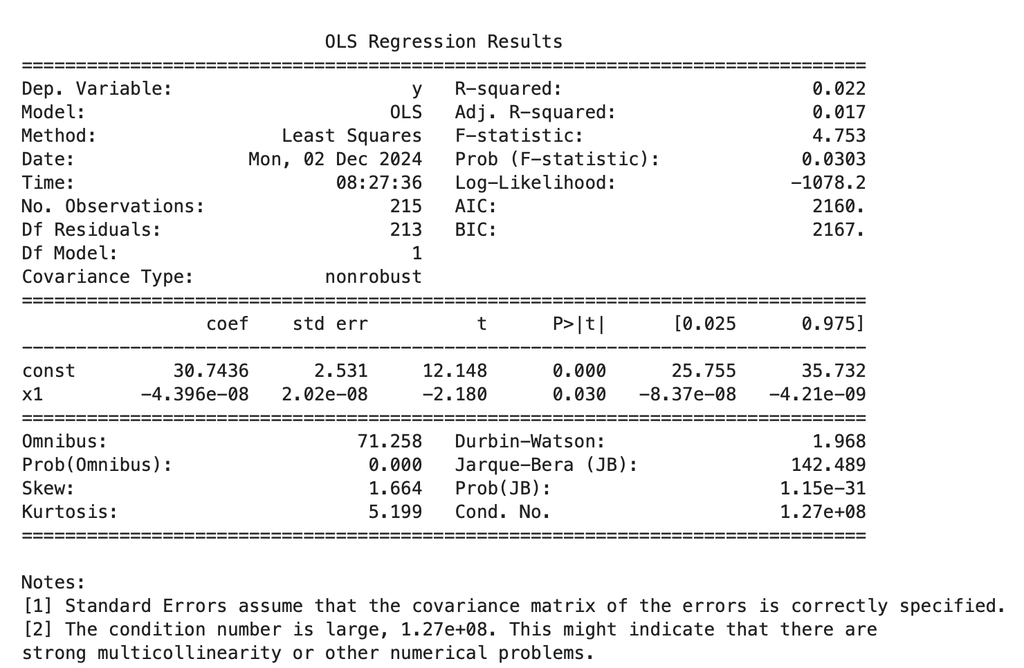

### Understanding Correlations Between Endowment Changes and Patent Concentrations

### Key Observations:

1. **Model**:
   - Independent variable: `endowment_diff`
   - Dependent variable: `Counts`

### Key Observations:

4. **Statistical Significance**:
   - The overall model's p-value (Prob(F-statistic)) is 0.0303, indicating that the model is statistically significant at the 5% level, though the relationship is not strong.

### Key Observations:

5. **Diagnostics**:
   - Durbin-Watson: 1.968 suggests no strong autocorrelation in residuals.
   - Omnibus and Jarque-Bera tests: Indicate non-normality of residuals (could require transformation or additional variables!).

### We Found Very **Little Correlation** Between University Endowment Spending (University Research) and Patents Filed (Innovation)

- Weak r$^2$ vaue suggests other factors likely play larger role in explaining patent filing concentrations
  - Makes sense! Oftentimes research is funded by outside organizations.
    - Better instrumental variable might've been papers published for university research proxy
  - Omnibus results imply that a Normality test was not suitable, so may have stronger relationship if using a different test.
- Original question was can these two variables quantify knowledge spillovers
  - Found a (weak) relationship, so endowment spending and patent concentrations are a decent starting block from which to investigate other potential quantifiers!

# Thank you!

#### Please feel free to contact me for further questions or discussion by email or on [LinkedIn](https://www.linkedin.com/in/mayaniyogi/)!